# Sphingobium LSP13 d3bxdA, growth in minimal medium with MBOA/BOA

Thoenen et al. AMPO formation

Christine Pestalozzi

2024-05-13

# 0. Packages installation

Set working directory to source file location

# 1. Data import & organization

Prepare metadata We read in all the data and then focus and plot the 0 uM, 500 uM and 1250 uM BX conditions and the corresponding Glc control to be consistent with the other analyses. Additional conditions were run at the same time and are not shown.

Load raw data and modify well labeling

Add time interval.

Combine the metadata with the raw data

# 2.density data

Calculate the absorbance increase relative to the start (Density delta)

Plot maximal absorbance to check if all strains grew in the control treatment. Plot the mean and individual points to check for differences between treatments

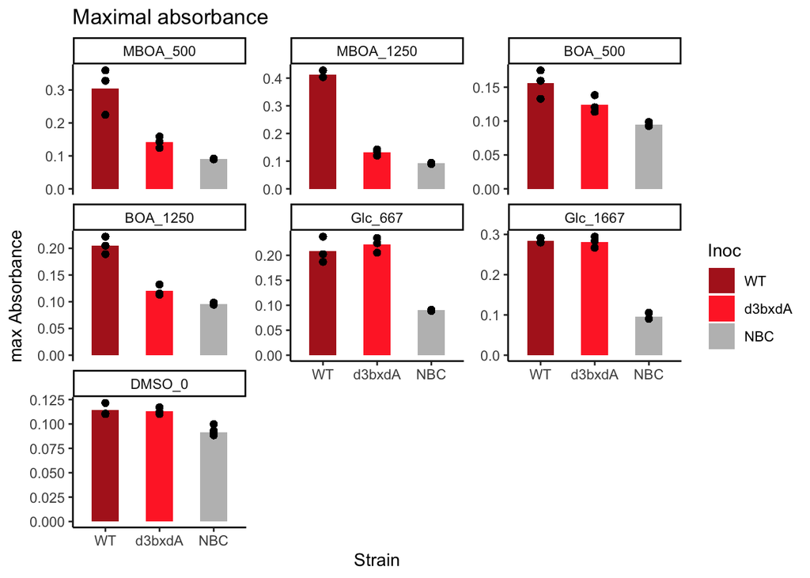

Check the replicates variation in each strain and condition combination.

# 3. Growth curves

FigS11a: mean and se plots of growth curves.

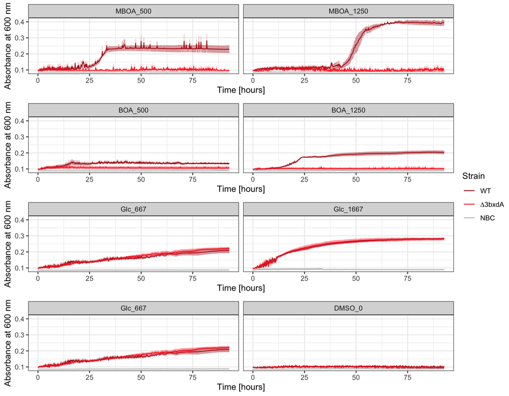

# 4. Area under the curve - growth

To quantify the total bacterial growth over time, we calculate the total area under the curve (AUC). This is done with the function “auc()”. We use the change in OD relative to the first measurement.

Fig 5e: Barplot of mean and the individual points for LSP13 wt and the triple bxdA mutant and the NBC for Figure 5e

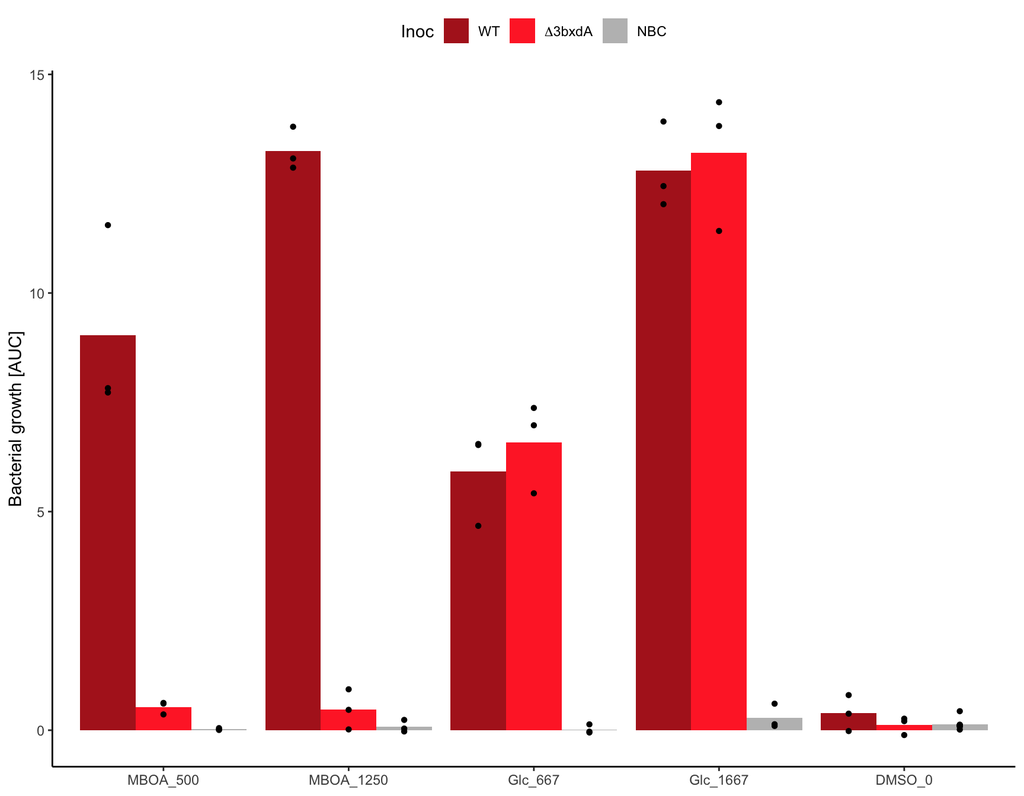

For additional comparison with BOA (500 and 1250 uM)

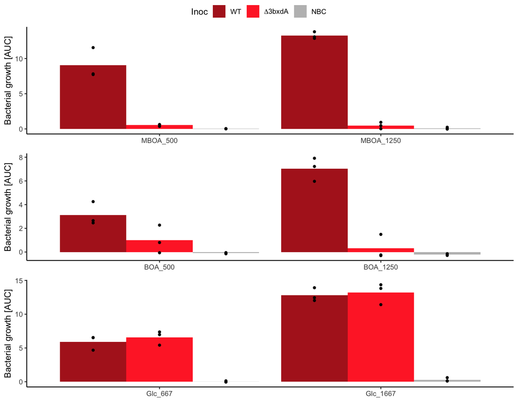